# HMDA Data Analysis and Prediction Model

## 6. Modeling

Decision Tree is simple, thus, it is often used as a baseline model. We will build a Decision Tree model with all features included, and then test other models like Logistics, Random Forest (*bagging*), Naive Bayes (*independence*), Gradient Boosting (*boosting*). Also, we will manipulate a feature set using Recursive Feature Elimination and Pinciple Component Analysis.

```python
# reduce the most class
second_large_supp = len(hmda_df[hmda_df['action_taken_name']=="Denied"])
size_drop = len(hmda_df[hmda_df['action_taken_name']=="Approved"]) - second_large_supp
drop_indice = np.random.choice(list(hmda_df[hmda_df['action_taken_name']=="Approved"].index),
                               size_drop, replace=False)

hmda_df = hmda_df.loc[~hmda_df.index.isin(drop_indice)]
```

```python
def split_X_y(df, features, y):
    cate_cols = df.select_dtypes(include='category').columns
    for col in cate_cols:
        le = ppr.LabelEncoder()
        le.fit(df[col])
        df[col] = le.transform(df[col])

    X = np.array(df[features])
    y = np.array(df[y])
    X_train, X_test, y_train, y_test = train_test_split(
        X, y, test_size=0.33)

    # normalize for faster calculation
    X_train = ppr.normalize(X_train)
    X_test = ppr.normalize(X_test)

    return X_train, X_test, y_train, y_test
```

```python
# all features
features = list(hmda_df.columns)
features.remove('action_taken_name')

# X, y
X_train, X_test, y_train, y_test = split_X_y(hmda_df, features, 'action_taken_name')
```

```python
# train and show scores
def train_evaluate(clf, X_train, X_test, y_train, y_test):
    clf.fit(X_train, y_train)
    pred = clf.predict(X_test)

    print("5-fold Cross Validation Accuracy:", round(cross_val_score(clf, X_train, y_train, cv=5).mean(), 2))
    print("\nConfusion Matrix\n", confusion_matrix(y_test, pred))
    print("\n", classification_report(y_test, pred))

    return clf
```

### • Baseline: *Decision Tree*

```python
clf_dt = train_evaluate(tree.DecisionTreeClassifier(), X_train, X_test, y_train, y_test)
```

```
5-fold Cross Validation Accuracy: 0.61

Confusion Matrix
 [[5718 3691]
 [3524 5863]]

              precision    recall  f1-score   support

          0       0.62      0.61      0.61      9409
          1       0.61      0.62      0.62      9387

avg / total       0.62      0.62      0.62     18796
```

The result is not so impressive, however, the errors are uniformly distributed at least.

### • Logistic Regression

```python
clf_lr = train_evaluate(LogisticRegression(), X_train, X_test, y_train, y_test)
```

```
5-fold Cross Validation Accuracy: 0.61

Confusion Matrix
 [[7944 1465]
 [5835 3552]]

              precision    recall  f1-score   support

          0       0.58      0.84      0.69      9409
          1       0.71      0.38      0.49      9387

avg / total       0.64      0.61      0.59     18796
```

### • Bagging: *Random Forest*

```python
clf_rf = train_evaluate(RandomForestClassifier(max_depth=20), X_train, X_test, y_train, y_test)
```

```
5-fold Cross Validation Accuracy: 0.66

Confusion Matrix
 [[6745 2664]
 [3460 5927]]

              precision    recall  f1-score   support

          0       0.66      0.72      0.69      9409
          1       0.69      0.63      0.66      9387

avg / total       0.68      0.67      0.67     18796
```

The result is better than the Decision Tree, but it is still so good.

### • Naive Bayes

```python
clf_nb = train_evaluate(GaussianNB(), X_train, X_test, y_train, y_test)
```

```
5-fold Cross Validation Accuracy: 0.58

Confusion Matrix
 [[8723  686]
 [6969 2418]]

              precision    recall  f1-score   support

          0       0.56      0.93      0.70      9409
          1       0.78      0.26      0.39      9387

avg / total       0.67      0.59      0.54     18796
```

### • Stochastic: *Gradient Boosting*

Gradient Boosting is a very sophisticated model to configurate parameters for the best performance. The following will seek the optimal parameters based on AUC scores.

```python
def roc_auc(clf, X_train, X_test, y_train, y_test):
    clf.fit(X_train, y_train)
    train_pred = clf.predict(X_train)
    fpr, tpr, thrd = roc_curve(y_train, train_pred)
    roc_auc_train = auc(fpr, tpr)

    test_pred = clf.predict(X_test)
    fpr, tpr, thrd = roc_curve(y_test, test_pred)
    roc_auc_test = auc(fpr, tpr)

    return roc_auc_train, roc_auc_test
```

```python
# learning rate
learning_rates = [1, 0.5, 0.25, 0.1, 0.05, 0.01]
lr_train = []
lr_test = []
for lr in learning_rates:
    clf_gb = GradientBoostingClassifier(learning_rate=lr)
    roc_auc_train, roc_auc_test = roc_auc(
        clf_gb, X_train, X_test, y_train, y_test)
    lr_train.append(roc_auc_train)
    lr_test.append(roc_auc_test)

# number of estimators
n_estimators = [1, 2, 4, 8, 16, 32, 64, 100, 150, 200]
est_train = []
est_test = []
for n in n_estimators:
    clf_gb = GradientBoostingClassifier(n_estimators=n)
    roc_auc_train, roc_auc_test = roc_auc(
        clf_gb, X_train, X_test, y_train, y_test)
    est_train.append(roc_auc_train)
    est_test.append(roc_auc_test)

# max depth
max_depths = np.arange(1, 16)
md_train = []
md_test = []
for d in max_depths:
    clf_gb = GradientBoostingClassifier(max_depth=d)
    roc_auc_train, roc_auc_test = roc_auc(
        clf_gb, X_train, X_test, y_train, y_test)
    md_train.append(roc_auc_train)
    md_test.append(roc_auc_test)

# max_features
max_features = list(range(1, len(features)))
mf_train = []
mf_test = []
for f in max_features:
    clf_gb = GradientBoostingClassifier(max_features=f)
    roc_auc_train, roc_auc_test = roc_auc(
        clf_gb, X_train, X_test, y_train, y_test)
    mf_train.append(roc_auc_train)
    mf_test.append(roc_auc_test)
```

```
Text(0.5,1,'Max Features')
```

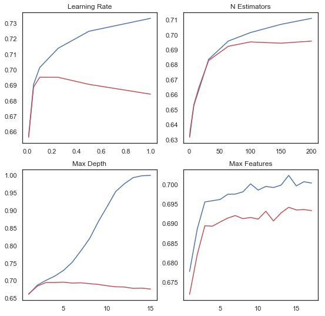

```python
fig, axes = plt.subplots(2, 2, figsize=(9, 9))

axes[0,0].plot(learning_rates, lr_train, 'b')
axes[0,0].plot(learning_rates, lr_test, 'r')
axes[0,0].set_title("Learning Rate")

axes[0,1].plot(n_estimators, est_train, 'b')
axes[0,1].plot(n_estimators, est_test, 'r')
axes[0,1].set_title("N Estimators")

axes[1,0].plot(max_depths, md_train, 'b')
axes[1,0].plot(max_depths, md_test, 'r')
axes[1,0].set_title("Max Depth")

axes[1,1].plot(max_features, mf_train, 'b')
axes[1,1].plot(max_features, mf_test, 'r')
axes[1,1].set_title("Max Features")
```

```python
clf_gb = train_evaluate(GradientBoostingClassifier(
        learning_rate=0.2,
        n_estimators=150,
        max_depth=7,
        max_features=5
    ), X_train, X_test, y_train, y_test)
```

```
5-fold Cross Validation Accuracy: 0.68

Confusion Matrix
 [[6833 2576]
 [3280 6107]]

              precision    recall  f1-score   support

          0       0.68      0.73      0.70      9409
          1       0.70      0.65      0.68      9387

avg / total       0.69      0.69      0.69     18796
```

### • Neural Network

Similar with Gradient Boosting, Neural Network need a certain set of parameters for tuning. This can be done using the Grid Search method.

```python
params = {
    'hidden_layer_sizes': [(50,50,50), (50,100,50), (100,)],
    'activation': ['tanh', 'relu'],
    'solver': ['sgd', 'adam'],
    'alpha': [0.0001, 0.001, 0.01],
    'learning_rate': ['constant','adaptive'],
}

clf = GridSearchCV(MLPClassifier(), params, n_jobs=-1, cv=3)
clf.fit(X_train, y_train)

print('Best parameters found:', clf.best_params_)
```

```
Best parameters found: {'activation': 'tanh', 'alpha': 0.0001, 'hidden_layer_sizes': (50, 100, 50), 'learning_rate': 'adaptive', 'solver': 'adam'}
```

```python
clf_mlp = train_evaluate(MLPClassifier(
                    alpha=0.001,
                    activation='relu',
                    solver='adam',
                    hidden_layer_sizes=(50,100,50),
                    learning_rate='constant'),
                X_train, X_test, y_train, y_test)
```

```
5-fold Cross Validation Accuracy: 0.65

Confusion Matrix
 [[8102 1307]
 [5343 4044]]

              precision    recall  f1-score   support

          0       0.60      0.86      0.71      9409
          1       0.76      0.43      0.55      9387

avg / total       0.68      0.65      0.63     18796
```

### • Feature Manipulation: *RFE, Heuristic*

```python
model = LogisticRegression()
rfe = RFE(model, 9).fit(X_train, y_train)

feature_rank = []
features_rfe = []

for feature, rank in zip(features, rfe.ranking_):
    feature_rank.append((feature, rank))
    if rank == 1:
        features_rfe.append(feature)

X_train_rfe, X_test_rfe, y_train_rfe, y_test_rfe = split_X_y(
    hmda_df, features_rfe, 'action_taken_name')

sorted(feature_rank, key=lambda tup : tup[1])
```

```
[('agency_abbr', 1),
 ('applicant_race_name_1', 1),
 ('minority_population', 1),
 ('income_sqrt', 1),
 ('loan_amount_sqrt', 1),
 ('tract_income_to_loan', 1),
 ('income_to_loan', 1),
 ('census_hier', 1),
 ('census_dbscan_1', 1),
 ('census_kmeans', 2),
 ('population', 3),
 ('loan_purpose_name', 4),
 ('co_applicant', 5),
 ('census_dbscan_2', 6),
 ('loan_type_name', 7),
 ('number_of_1_to_4_family_units', 8),
 ('number_of_owner_occupied_units', 9),
 ('applicant_sex_name', 10)]
```

```python
clf_lr_rfe = train_evaluate(LogisticRegression(), X_train_rfe, X_test_rfe, y_train_rfe, y_test_rfe)
```

```
5-fold Cross Validation Accuracy: 0.65

Confusion Matrix
 [[6621 2692]
 [3971 5512]]

              precision    recall  f1-score   support

          0       0.63      0.71      0.67      9313
          1       0.67      0.58      0.62      9483

avg / total       0.65      0.65      0.64     18796
```

Selecting 9 of half the features, the f1-score of Logistic Regression is improved from 0.59. This indicates that the features had too much interaction to interfere with our target classes. Now, we can take this into consideration to select features in a heuristic way. The rule is to include features that care less correlated and use the Naive Bayes model which assumes independence among features.

```python
features_comb = ['agency_abbr', 'applicant_sex_name', 'minority_population', 'income_to_loan',
                 'loan_purpose_name', 'loan_type_name', 'co_applicant',
                 'census_kmeans', 'census_dbscan_1', 'census_hier',
                 'number_of_1_to_4_family_units', 'number_of_owner_occupied_units']

X_train_comb, X_test_comb, y_train_comb, y_test_comb = split_X_y(
    hmda_df, features_comb, 'action_taken_name')
```

```python
clf_nb_comb = train_evaluate(GaussianNB(), X_train_comb, X_test_comb, y_train_comb, y_test_comb)
```

```
5-fold Cross Validation Accuracy: 0.6

Confusion Matrix
 [[6179 3188]
 [4227 5202]]

              precision    recall  f1-score   support

          0       0.59      0.66      0.62      9367
          1       0.62      0.55      0.58      9429

avg / total       0.61      0.61      0.60     18796
```

### • Principle Component Analysis

PCA takes a totally differnt look at features in that RFE and other feature selection methods simply include/exclude features. For that reason, we can hardly say which feature makes how much contributions.

```python
reduced_df = df_reducer(hmda_df, 10000)

X_train_pca, X_test_pca, y_train_pca, y_test_pca = split_X_y(
    reduced_df, features_rfe, 'action_taken_name')

pca = PCA(n_components=5)
pca.fit(X_train_pca)

X_train_pca = pca.transform(X_train_pca)
X_test_pca = pca.transform(X_test_pca)

clf_pca = SVC(C=5, gamma=10)
clf_pca.fit(X_train_pca, y_train_pca)

print(pca.explained_variance_ratio_)

train_evaluate(clf_pca, X_train_pca, X_test_pca, y_train_pca, y_test_pca)
```

```
[0.77424267 0.10446486 0.05925091 0.03537464 0.01358645]
5-fold Cross Validation Accuracy: 0.66

Confusion Matrix
 [[1326  342]
 [ 809  823]]

              precision    recall  f1-score   support

          0       0.62      0.79      0.70      1668
          1       0.71      0.50      0.59      1632

avg / total       0.66      0.65      0.64      3300
```

```
SVC(C=5, cache_size=200, class_weight=None, coef0=0.0,
  decision_function_shape='ovr', degree=3, gamma=10, kernel='rbf',
  max_iter=-1, probability=False, random_state=None, shrinking=True,
  tol=0.001, verbose=False)
```

### • Voting Ensemble

So far, we have found out that Gradient Boosting works the best followed by Random Forest. What we can do with these is mixing them together to make them vote. Also, we can add Naive Bayes because the model is fundamentally different. Voting Ensemble is useful when a certain level of diversity is secured.

```python
estimators = []

estimators.append(('nb', clf_nb))
estimators.append(('rf', clf_rf))
estimators.append(('gb', clf_gb))

ensemble = VotingClassifier(estimators)
clf_ens = train_evaluate(ensemble, X_train, X_test, y_train, y_test)
```

```
5-fold Cross Validation Accuracy: 0.68

Confusion Matrix
 [[7470 1939]
 [4048 5339]]

              precision    recall  f1-score   support

          0       0.65      0.79      0.71      9409
          1       0.73      0.57      0.64      9387

avg / total       0.69      0.68      0.68     18796
```

## 7. Conclusion

Through the data analysis, we learnt the following patterns.

- **Income and loan amount are correlated, and the larger they are the higher chance to get approval**
- **Higher minority population rate affects mortgage loan results negatively**
- **Low minority population rate has a weak influence on approval**
- **A white male is more likely to get approval then a black female**
- **Racial/Sex factors become insignificant as loan amount and income increase**
- **Home purchase is the best purpose for approval**

However, these patterns are not so strong that it was difficult to clearly cut the groups. There were such interactions among features that classifying observations in one way would be no longer the same if in another way. Figuratively speaking, observations were tangled even in a finely separated group. For example, two cases having almost or exact the same condition would be classified differently; Approved and Denied, repectively.

To solve this, we used sophisticated models like Gradient Boosting and MLP. Also, we tried a different feature set as well as PCA. However, the entanglement was at a serious level making the best model performance around 0.7 accuracy and f1-score.

## Reference

**Dataset**

- [Metadata1](https://cfpb.github.io/api/hmda/fields.html)
- [Metadata2](https://www.ffiec.gov/hmda/glossary.htm)
- [Census Tract](https://censusreporter.org/profiles/14000US29510118400-census-tract-1184-st-louis-mo/)

**Theory and Syntax**

- [Clustering Overview](https://scikit-learn.org/stable/modules/clustering.html#hierarchical-clustering)
- [Hierarchical Clustering](https://stackabuse.com/hierarchical-clustering-with-python-and-scikit-learn/)
- [DBSCAN](http://iopscience.iop.org/article/10.1088/1755-1315/31/1/012012/pdf)
- [PyMongo Tutorial](http://api.mongodb.com/python/current/tutorial.html), [PyMongo DB to CSV](https://gist.github.com/mieitza/5d35d0a4f2671127f7120c75c8764385)
- [Imbalanced Data](https://machinelearningmastery.com/tactics-to-combat-imbalanced-classes-in-your-machine-learning-dataset/)
- [Curse of Dimensionality](http://www.visiondummy.com/2014/04/curse-dimensionality-affect-classification/)
- [Ensemble](https://machinelearningmastery.com/ensemble-machine-learning-algorithms-python-scikit-learn/)
- [SVC C Parameter](https://stats.stackexchange.com/questions/31066/what-is-the-influence-of-c-in-svms-with-linear-kernel)